# part3

me

12 joulukuuta 2019

# Traits analyysi

## Aineisto sisään ja taulukoiden kokoaminen

```r
#yhdistetään ennustustarkkuustulokset ja lajiominaisuudet samaan taulukkoon
res<-read.csv("results_and_pooled.csv")
traits<-read.csv("traits_table.csv",sep = ";")
results<-inner_join(res,traits,by="species")
#tallenna tarvittaessa omaksi taulukokseen
#write.csv(res,"accuracies_traits.csv",row.names = F)
```

Tarkastellaan aineistoa kuvaajista:

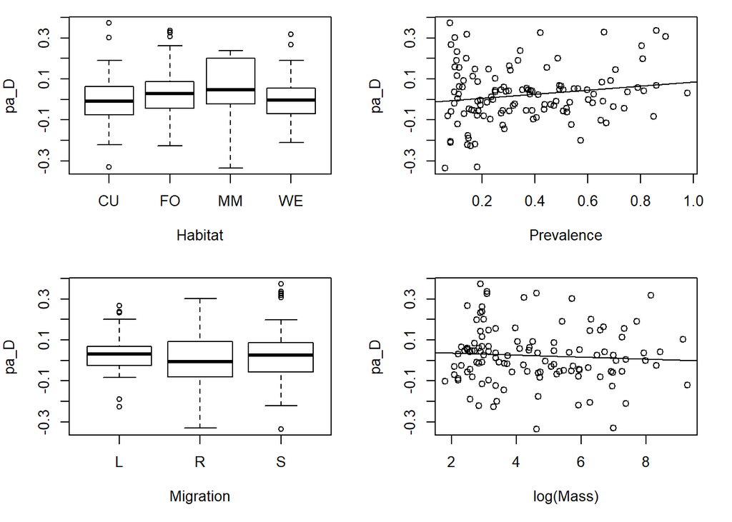

```r
#kuvaajien piirtely ei (ainakaan multa) onnistu jos log(Mass) ei ole valmiiksi laskettu omaan
#sarakkeeseensa
results$logmass<-log(results$Mass)
#pa aineisto
op<-par(mfrow=c(2,2),mar=c(5,4,1,2))
boxplot(pa_D~Hab,data=results,ylab="pa_D",xlab="Habitat")
plot(pa_D~Prev, data = results,ylab="pa_D",xlab="Prevalence")
abline(lm(pa_D~Prev,data = results))
boxplot(pa_D~Mig,data=results,ylab="pa_D",xlab="Migration")
plot(pa_D~logmass, data = results,ylab="pa_D",xlab="log(Mass)")
abline(lm(pa_D~logmass,data = results))
```

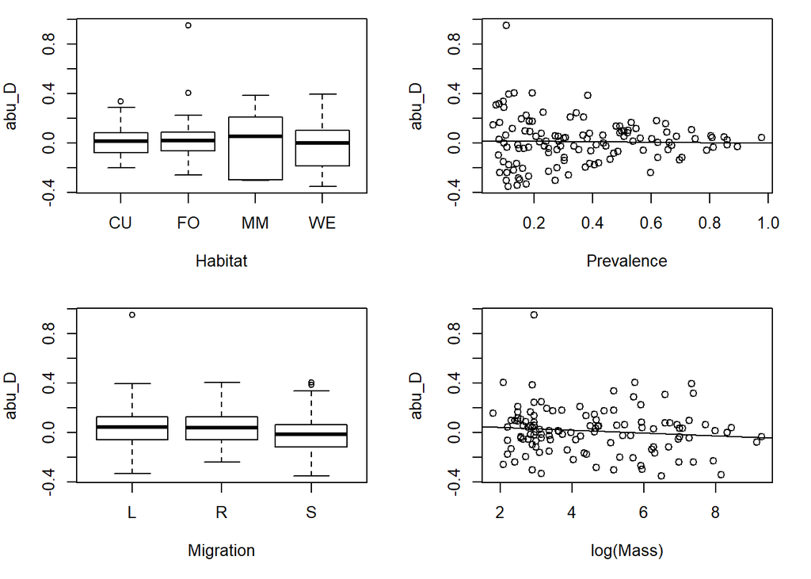

```r
par(op)

#abu aineisto
op<-par(mfrow=c(2,2),mar=c(5,4,1,2))
boxplot(abu_D~Hab,data=results,ylab="abu_D",xlab="Habitat")
plot(abu_D~Prev, data = results,ylab="abu_D",xlab="Prevalence")
abline(lm(abu_D~Prev,data = results))
boxplot(abu_D~Mig,data=results,ylab="abu_D",xlab="Migration")
plot(abu_D~logmass, data = results,ylab="abu_D",xlab="log(Mass)")
abline(lm(abu_D~logmass,data = results))
```

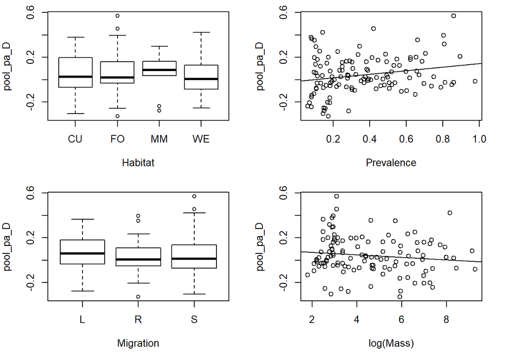

```r
par(op)

#poolattu pa aineisto
op<-par(mfrow=c(2,2),mar=c(5,4,1,2))
boxplot(pool_pa_change~Hab,data=results,ylab="pool_pa_D",xlab="Habitat")
plot(pool_pa_change~Prev, data = results,ylab="pool_pa_D",xlab="Prevalence")
abline(lm(pool_pa_change~Prev,data = results))
boxplot(pool_pa_change~Mig,data=results,ylab="pool_pa_D",xlab="Migration")
plot(pool_pa_change~logmass, data = results,ylab="pool_pa_D",xlab="log(Mass)")
abline(lm(pool_pa_change~logmass,data = results))
```

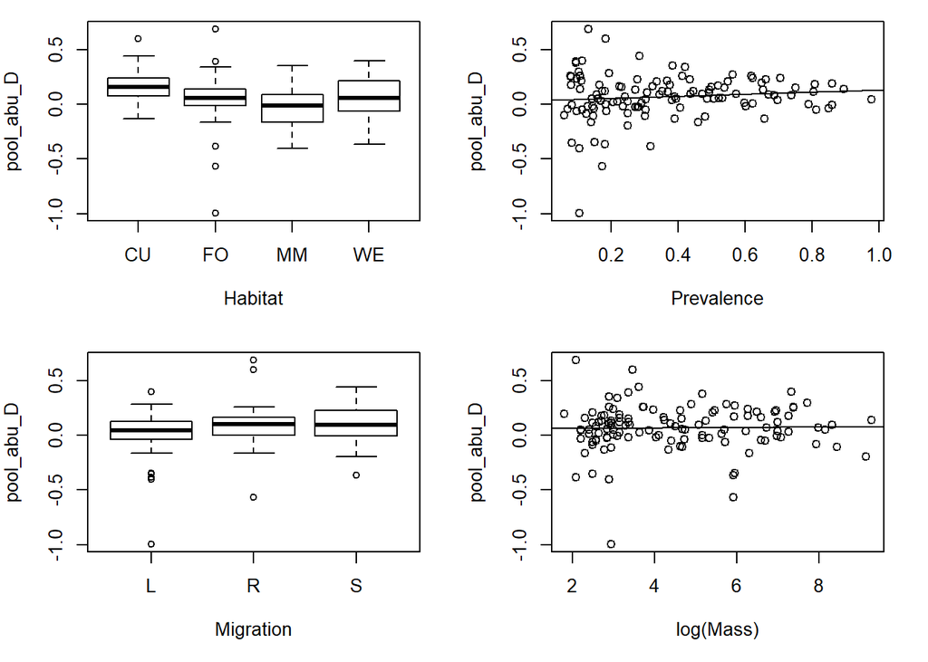

```r
par(op)

#poolattu abu aineisto
op<-par(mfrow=c(2,2),mar=c(5,4,1,2))
boxplot(pool_abu_change~Hab,data=results,ylab="pool_abu_D",xlab="Habitat")
plot(pool_abu_change~Prev, data = results,ylab="pool_abu_D",xlab="Prevalence")
abline(lm(pool_abu_change~Prev,data = results))
boxplot(pool_abu_change~Mig,data=results,ylab="pool_abu_D",xlab="Migration")
plot(pool_abu_change~logmass, data = results,ylab="pool_abu_D",xlab="log(Mass)")
abline(lm(pool_abu_change~logmass,data = results))
```

```r
par(op)
```

## Fylogenian huomioinen lajien ominaisuuksia tarkastellessa

BirdTree.org palvelusta on haettu lintujen sukupuu (tai itseasiassa tiedosto sisältää 100 vaihtoehtoista sukupuuta, joista valitaan yksi).

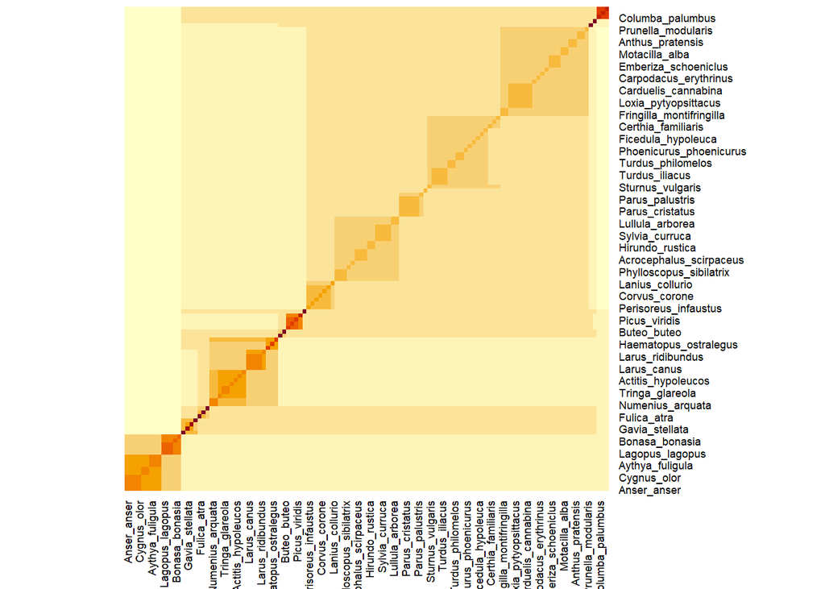

```r
#luetaan aineisto sisään, Multiphylo eli monta puuta
linnut <- read.nexus("output.nex")
#valitaan vain yksi puu, mikä tahansa sadasta
linnut2<-linnut[[99]]
#define a variance-covariance structure based on the model of Brownian evolution
bm.birds=corBrownian(1,phy=linnut2)
#tehdään fylogenialistasta matriisi
lintupuu<-vcv.phylo(linnut2)
#matriisin voi värittää havainnollistamaan lintulajien sukulaisuutta
heatmap(lintupuu,Rowv = NA,Colv = NA)
```

```r
#aineiston rivien nimet muutetaan lattareiksi jolloin keskustelee fylogeniapuun kanssa
rownames(results)=results$species
```

“the so called Brownian motion (also called random walk or diffusion) 3191 model of trait evolution, which is the simplest model among the many alternative models of how 3192 traits might evolve (Beaulieu et al., 2012).”

## Traits-analyysit

Selvitetään, vaikuttavatko lajien ominaisuudet (muuttokäyttäytyminen ‘Mig’, elinympäristö ‘Hab’, paino ‘logMass’ tai prevalenssi ‘Prev’) ennustustarkkuuteen. Analyysissä pitäisi huomioida, että lajit voivat olla ominaisuuksiltaan samankaltaisia (ja siten omata myös yhtä suuret ennustustarkkuudet) läheisen sukulaisuussuhteen takia.

### Ei-poolatulle, 2x2 km aineistolle

#### pa-aineisto

Vertailun vuoksi teen ensin analyysit huomioimatta fylogeniaa ja sen jälkeen fylogenia huomioiden.  
Ensin ilman fylogeniaa:

```r
#luodaan eri mallivaihtoehtoja
malli0 <- gls(pa_D ~ 1, data = results)
malli1 <- gls(pa_D ~ Mig, data = results)
malli2 <- gls(pa_D ~ Hab, data = results)
malli3 <- gls(pa_D ~ log(Mass), data = results)
malli4 <- gls(pa_D ~ Prev, data = results)
malli5 <- gls(pa_D ~ Mig + Hab, data = results)
malli6 <- gls(pa_D ~ Hab + log(Mass), data = results)
malli7 <- gls(pa_D ~ Mig + log(Mass), data = results)
malli8 <- gls(pa_D ~ log(Mass)+Prev, data = results)
malli9 <- gls(pa_D ~ Mig +Prev, data = results)
malli10 <- gls(pa_D ~ Hab+Prev, data = results)
malli11 <- gls(pa_D ~ Mig + Hab + log(Mass), data = results)
malli12 <- gls(pa_D ~ Mig + Hab + Prev, data = results)
malli13 <- gls(pa_D ~ Mig + Prev + log(Mass), data = results)
malli14 <- gls(pa_D ~ Prev + Hab + log(Mass), data = results)
malli15 <- gls(pa_D ~ Mig + Hab + log(Mass)+Prev, data = results)

#mallin valintaa MuMin paketin avulla
output1<-model.sel(malli0,malli1,malli2,malli3,malli4,malli5,malli6,malli7,malli8,malli9,malli10,malli11,malli12,malli13,malli14,malli15)

# AICc Table
output1
```

```
## Model selection table
##             (Int) Mig Hab   log(Mss)     Prv df logLik   AICc delta weight
## malli0   0.023390                             2 65.907 -127.7  0.00  0.794
## malli4  -0.012100                    0.09768  3 65.569 -124.9  2.78  0.198
## malli3   0.045730         -0.0049650          3 62.090 -118.0  9.74  0.006
## malli8  -0.005717         -0.0011700 0.09460  4 61.533 -114.7 12.99  0.001
## malli1   0.034080   +                         4 61.007 -113.7 14.05  0.001
## malli9  -0.003833   +                0.10030  5 60.734 -110.9 16.77  0.000
## malli2   0.004602       +                     5 59.679 -108.8 18.88  0.000
## malli10 -0.030640       +            0.09850  6 59.097 -105.5 22.26  0.000
## malli7   0.053100   +     -0.0056750          5 57.318 -104.1 23.60  0.000
## malli13  0.001691   +     -0.0013010 0.09718  6 56.819 -100.9 26.82  0.000
## malli6   0.011670       + -0.0016810          6 55.783  -98.8 28.89  0.000
## malli5   0.014840   +   +                     7 55.234  -95.5 32.24  0.000
## malli14 -0.030520       + -0.0000259 0.09847  7 55.180  -95.4 32.35  0.000
## malli12 -0.019780   +   +            0.09035  8 54.432  -91.6 36.15  0.000
## malli11  0.017240   +   + -0.0007977          8 51.426  -85.6 42.16  0.000
## malli15 -0.022310   +   +  0.0007577 0.09100  9 50.625  -81.6 46.10  0.000
## Models ranked by AICc(x)
```

Malli0 näyttäisi olevan näistä paras. Mikään ei siis selitä ennustustarkkuutta.

```r
# Parameter estimate Table, katsotaan tarkemmin parasta mallia
summary(malli0)
```

```
## Generalized least squares fit by REML
##   Model: pa_D ~ 1
##   Data: results
##         AIC       BIC   logLik
##   -127.8149 -122.2567 65.90746
##
## Coefficients:
##                  Value  Std.Error  t-value p-value
## (Intercept) 0.02339156 0.01244241 1.879985  0.0626
##
## Standardized residuals:
##         Min          Q1         Med          Q3         Max
## -2.63600976 -0.57603783  0.01635934  0.44798471  2.56515921
##
## Residual standard error: 0.1362998
## Degrees of freedom: 120 total; 119 residual
```

Samat mallit fylogenia huomioiden:

```r
#sama fylogenia huomioiden
#luodaan eri mallivaihtoehtoja
malli0 <- gls(pa_D ~ 1, data = results,correlation=bm.birds,method="ML" )
malli1 <- gls(pa_D ~ Mig, data = results,correlation=bm.birds,method="ML")
malli2 <- gls(pa_D ~ Hab, data = results,correlation=bm.birds,method="ML")
malli3 <- gls(pa_D ~ log(Mass), data = results,correlation=bm.birds,method="ML")
malli4 <- gls(pa_D ~ Prev, data = results,correlation=bm.birds,method="ML")
malli5 <- gls(pa_D ~ Mig + Hab, data = results,correlation=bm.birds,method="ML")
malli6 <- gls(pa_D ~ Hab + log(Mass), data = results,correlation=bm.birds,method="ML")
malli7 <- gls(pa_D ~ Mig + log(Mass), data = results,correlation=bm.birds,method="ML")
malli8 <- gls(pa_D ~ log(Mass)+Prev, data = results,correlation=bm.birds,method="ML")
malli9 <- gls(pa_D ~ Mig +Prev, data = results,correlation=bm.birds,method="ML")
malli10 <- gls(pa_D ~ Hab+Prev, data = results,correlation=bm.birds,method="ML")
malli11 <- gls(pa_D ~ Mig + Hab + log(Mass), data = results,correlation=bm.birds,method="ML")
malli12 <- gls(pa_D ~ Mig + Hab + Prev, data = results,correlation=bm.birds,method="ML")
malli13 <- gls(pa_D ~ Mig + Prev + log(Mass), data = results,correlation=bm.birds,method="ML")
malli14 <- gls(pa_D ~ Prev + Hab + log(Mass), data = results,correlation=bm.birds,method="ML")
malli15 <- gls(pa_D ~ Mig + Hab + log(Mass)+Prev, data = results,correlation=bm.birds,method="ML")

#mallin valintaa MuMin paketin avulla
output1<-model.sel(malli0,malli1,malli2,malli3,malli4,malli5,malli6,malli7,malli8,malli9,malli10,malli11,malli12,malli13,malli14,malli15)

# AICc Table
output1
```

```
## Model selection table
##            (Int) Mig Hab log(Mss)      Prv df logLik  AICc delta weight
## malli3  0.263400         -0.04292           3 16.311 -26.4  0.00  0.347
## malli8  0.332400         -0.05167 -0.05576  4 17.102 -25.9  0.56  0.262
## malli0  0.001830                            2 14.120 -24.1  2.28  0.111
## malli7  0.282500   +     -0.03868           5 16.980 -23.4  2.98  0.078
## malli13 0.341100   +     -0.04705 -0.04941  6 17.593 -22.4  3.97  0.048
## malli4  0.007748                  -0.02100  3 14.240 -22.3  4.14  0.044
## malli1  0.060020   +                        4 15.238 -22.1  4.29  0.041
## malli6  0.257300       + -0.04118           6 16.850 -21.0  5.46  0.023
## malli9  0.063470   +              -0.01626  5 15.311 -20.1  6.32  0.015
## malli14 0.323100       + -0.04952 -0.05091  7 17.468 -19.9  6.48  0.014
## malli2  0.006819       +                    5 14.825 -19.1  7.29  0.009
## malli11 0.277900   +   + -0.03823           8 17.211 -17.1  9.29  0.003
## malli10 0.011120       +          -0.01446  6 14.880 -17.0  9.40  0.003
## malli5  0.059920   +   +                    7 15.506 -16.0 10.40  0.002
## malli15 0.337000   +   + -0.04639 -0.04756  9 17.749 -15.9 10.55  0.002
## malli12 0.063320   +   +          -0.01285  8 15.550 -13.8 12.61  0.001
## Models ranked by AICc(x)
```

Malli 3 ja 8 ovat melkein yhtä hyviä. Malli 3 on yksinkertaisempi. Sen mukaan paino olisi selittävä tekijä.

```r
#tehdään model averaging
summary(model.avg(output1, revised.var = TRUE))
```

```
##
## Call:
## model.avg(object = output1, revised.var = TRUE)
##
## Component model call:
## gls(model = <16 unique values>, data = results, correlation =
##      bm.birds, method = ML)
##
## Component models:
##        df logLik   AICc delta weight
## 3       3  16.31 -26.42  0.00   0.35
## 34      4  17.10 -25.86  0.56   0.26
## (Null)  2  14.12 -24.14  2.28   0.11
## 13      5  16.98 -23.43  2.98   0.08
## 134     6  17.59 -22.44  3.97   0.05
## 4       3  14.24 -22.27  4.14   0.04
## 1       4  15.24 -22.13  4.29   0.04
## 23      6  16.85 -20.96  5.46   0.02
## 14      5  15.31 -20.09  6.32   0.01
## 234     7  17.47 -19.94  6.48   0.01
## 2       5  14.83 -19.12  7.29   0.01
## 123     8  17.21 -17.13  9.29   0.00
## 24      6  14.88 -17.02  9.40   0.00
## 12      7  15.51 -16.01 10.40   0.00
## 1234    9  17.75 -15.86 10.55   0.00
## 124     8  15.55 -13.80 12.61   0.00
##
## Term codes:
##       Mig       Hab log(Mass)      Prev
##         1         2         3         4
##
## Model-averaged coefficients:
## (full average)
##               Estimate Std. Error Adjusted SE z value Pr(>|z|)
## (Intercept)  0.2325124  0.2429273   0.2448509   0.950    0.342
## log(Mass)   -0.0354784  0.0269398   0.0270738   1.310    0.190
## Prev        -0.0189413  0.0375279   0.0377444   0.502    0.616
## MigR        -0.0120607  0.0399021   0.0401503   0.300    0.764
## MigS        -0.0107306  0.0315924   0.0317561   0.338    0.735
## HabFO        0.0003867  0.0106677   0.0107784   0.036    0.971
## HabMM        0.0023568  0.0172283   0.0173513   0.136    0.892
## HabWE       -0.0013211  0.0179567   0.0181308   0.073    0.942
##
## (conditional average)
##              Estimate Std. Error Adjusted SE z value Pr(>|z|)
## (Intercept)  0.232512   0.242927    0.244851   0.950   0.3423
## log(Mass)   -0.045757   0.021580    0.021795   2.099   0.0358 *
## Prev        -0.048944   0.046591    0.047040   1.040   0.2981
## MigR        -0.063992   0.071587    0.072319   0.885   0.3762
## MigS        -0.056935   0.051624    0.052154   1.092   0.2750
## HabFO        0.006901   0.044566    0.045039   0.153   0.8782
## HabMM        0.042063   0.060227    0.060854   0.691   0.4894
## HabWE       -0.023579   0.072319    0.073090   0.323   0.7470
## ---
## Signif. codes:  0 '***' 0.001 '**' 0.01 '*' 0.05 '.' 0.1 ' ' 1
```

Luettiinko model averaging taulukosta full average-arvoja? Sen mukaan mikään muuttuja (ei edes paino) ei selitä ennustustarkkuutta.

The ‘subset’ (or ‘conditional’) average only averages over the models where the parameter appears. An alternative, the ‘full’ average assumes that a variable is included in every model, but in some models the corresponding coefficient (and its respective variance) is set to zero. Unlike the ‘subset average’, it does not have a tendency of biasing the value away from zero. The ‘full’ average is a type of shrinkage estimator and for variables with a weak relationship to the response they are smaller than ‘subset’ estimators. Lisää voi lukea [täältä](https://theoreticalecology.wordpress.com/2018/05/14/model-averaging-in-ecology-a-review-of-bayesian-information-theoretic-and-tactical-approaches-for-predictive-inference/).

```r
# Parameter estimate Table, katsotaan tarkemmin parasta mallia
summary(malli3)
```

```
## Generalized least squares fit by maximum likelihood
##   Model: pa_D ~ log(Mass)
##   Data: results
##         AIC       BIC   logLik
##   -26.62286 -18.26038 16.31143
##
## Correlation Structure: corBrownian
##  Formula: ~1
##  Parameter estimate(s):
## numeric(0)
##
## Coefficients:
##                   Value  Std.Error   t-value p-value
## (Intercept)  0.26342417 0.21628878  1.217928  0.2257
## log(Mass)   -0.04292374 0.02048712 -2.095157  0.0383
##
##  Correlation:
##           (Intr)
## log(Mass) -0.577
##
## Standardized residuals:
##        Min         Q1        Med         Q3        Max
## -0.9301602 -0.2942655 -0.1595115  0.1105368  0.9340330
##
## Residual standard error: 0.4313473
## Degrees of freedom: 120 total; 118 residual
```

Paino näyttäisi olevan merkitsevä, mutta rajoilla.